# PredictionS

```r
library(caret)
library(randomForest)
df <- read.csv("pml-training.csv")
str(df)
```

```
## 'data.frame':    19622 obs. of  160 variables:
##  $ X                       : int  1 2 3 4 5 6 7 8 9 10 ...
##  $ user_name               : Factor w/ 6 levels "adelmo","carlitos",..: 2 2 2 2 2 2 2 2 2 2 ...
##  $ raw_timestamp_part_1    : int  1323084231 1323084231 1323084231 1323084232 1323084232 1323084232 1323084232 1323084232 1323084232 1323084232 ...
##  $ raw_timestamp_part_2    : int  788290 808298 820366 120339 196328 304277 368296 440390 484323 484434 ...
##  $ cvtd_timestamp          : Factor w/ 20 levels "02/12/2011 13:32",..: 9 9 9 9 9 9 9 9 9 9 ...
##  $ new_window              : Factor w/ 2 levels "no","yes": 1 1 1 1 1 1 1 1 1 1 ...
##  $ num_window              : int  11 11 11 12 12 12 12 12 12 12 ...
##  $ roll_belt               : num  1.41 1.41 1.42 1.48 1.48 1.45 1.42 1.42 1.43 1.45 ...
##  $ pitch_belt              : num  8.07 8.07 8.07 8.05 8.07 8.06 8.09 8.13 8.16 8.17 ...
##  $ yaw_belt                : num  -94.4 -94.4 -94.4 -94.4 -94.4 -94.4 -94.4 -94.4 -94.4 -94.4 ...
##  $ total_accel_belt        : int  3 3 3 3 3 3 3 3 3 3 ...
##  $ kurtosis_roll_belt      : Factor w/ 397 levels "","-0.016850",..: 1 1 1 1 1 1 1 1 1 1 ...
##  $ kurtosis_picth_belt     : Factor w/ 317 levels "","-0.021887",..: 1 1 1 1 1 1 1 1 1 1 ...
##  $ kurtosis_yaw_belt       : Factor w/ 2 levels "","#DIV/0!": 1 1 1 1 1 1 1 1 1 1 ...
```

[output cut: 86 more lines]

The Feature or the variable consitiutes to about 160 . Also many feature or variable have factors of abot 340 Levels . Therefore the complexity of dataset is too high to even attempt to model the dataset

```r
df[,colSums(is.na(df)) <= 0] -> X
subset(X,select=-c(min_yaw_forearm,max_yaw_forearm,skewness_pitch_forearm,skewness_roll_forearm,kurtosis_picth_forearm,kurtosis_roll_forearm,max_yaw_dumbbell,min_yaw_dumbbell)) -> X
subset(X,select=-c(kurtosis_roll_dumbbell,kurtosis_roll_dumbbell, skewness_roll_dumbbell,skewness_pitch_dumbbell, kurtosis_roll_arm,kurtosis_picth_arm,kurtosis_yaw_arm,skewness_roll_arm,skewness_pitch_arm, skewness_yaw_arm))-> X
```

Continuing to truncate down the Observations or Variables which are Null, have too many levels or does not provide any stastical information to response like timestamp

```r
subset(X,select=-c(X))-> X
subset(X,select=-c(user_name,raw_timestamp_part_1,raw_timestamp_part_2,cvtd_timestamp,  yaw_belt, kurtosis_roll_belt,kurtosis_picth_belt, skewness_roll_belt,skewness_roll_belt.1,max_yaw_belt,min_yaw_belt ))-> X
str(X)
```

```
## 'data.frame':    19622 obs. of  64 variables:
##  $ new_window             : Factor w/ 2 levels "no","yes": 1 1 1 1 1 1 1 1 1 1 ...
##  $ num_window             : int  11 11 11 12 12 12 12 12 12 12 ...
##  $ roll_belt              : num  1.41 1.41 1.42 1.48 1.48 1.45 1.42 1.42 1.43 1.45 ...
##  $ pitch_belt             : num  8.07 8.07 8.07 8.05 8.07 8.06 8.09 8.13 8.16 8.17 ...
##  $ total_accel_belt       : int  3 3 3 3 3 3 3 3 3 3 ...
##  $ kurtosis_yaw_belt      : Factor w/ 2 levels "","#DIV/0!": 1 1 1 1 1 1 1 1 1 1 ...
##  $ skewness_yaw_belt      : Factor w/ 2 levels "","#DIV/0!": 1 1 1 1 1 1 1 1 1 1 ...
##  $ amplitude_yaw_belt     : Factor w/ 4 levels "","#DIV/0!","0.00",..: 1 1 1 1 1 1 1 1 1 1 ...
##  $ gyros_belt_x           : num  0 0.02 0 0.02 0.02 0.02 0.02 0.02 0.02 0.03 ...
##  $ gyros_belt_y           : num  0 0 0 0 0.02 0 0 0 0 0 ...
##  $ gyros_belt_z           : num  -0.02 -0.02 -0.02 -0.03 -0.02 -0.02 -0.02 -0.02 -0.02 0 ...
##  $ accel_belt_x           : int  -21 -22 -20 -22 -21 -21 -22 -22 -20 -21 ...
##  $ accel_belt_y           : int  4 4 5 3 2 4 3 4 2 4 ...
##  $ accel_belt_z           : int  22 22 23 21 24 21 21 21 24 22 ...
```

[output cut: 50 more lines]

ThE Variable or observation now stands at about 64 Variable

However the no of feature or variable are still too high and recursive feature elimination is still need to be used for further eliminating the variables

For feature elimination random function would be used with bootstrap as the sampling. The no of sampled bootstraped is also limited to 2 as no of observation is very high

The reason to choose bootstrap as the model evaluation technique is because the cross validation would be too expensive to compute with 64 predictors. Also bootstrap would give us a reasonable good perfomance considering the large no of observations

```r
subset(X,select=-c(  kurtosis_picth_dumbbell))-> X
control <- rfeControl(functions=rfFuncs,method = "boot",number = 2)
results <- rfe(X[,1:62], X[,63],rfeControl=control)
predictors(results)
```

```
## [1] "num_window"        "roll_belt"         "magnet_dumbbell_z"
## [4] "pitch_belt"
```

The rfe have now reduced the no of total possible variables to only 4 which seem to have any effect on response variable

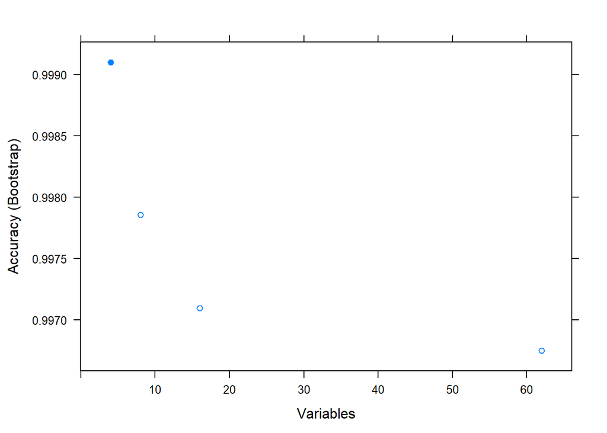

```r
plot(results)
```

The Plot shows The Accuracy obtained is 0.9990 from 4 predictors which is astouding

To imagine how out of 160 variable only a handful of predictors have any say on response variable is marvellous

```r
Subset <- subset(X,select=c(num_window,roll_belt,magnet_dumbbell_z,pitch_belt,classe))
read.csv("pml-testing.csv") -> DF1
Subset1 <- subset(DF1,select=c(num_window,roll_belt,magnet_dumbbell_z,pitch_belt))
```

Loading the testing dataset with necessary variables

```r
control <- trainControl(method="cv", number=5)

train(classe~.,data=Subset,method = "rf",trainControl=control) -> Training
```

```r
Training
```

```
## Random Forest
##
## 19622 samples
##     4 predictor
##     5 classes: 'A', 'B', 'C', 'D', 'E'
##
## No pre-processing
## Resampling: Bootstrapped (25 reps)
## Summary of sample sizes: 19622, 19622, 19622, 19622, 19622, 19622, ...
## Resampling results across tuning parameters:
##
##   mtry  Accuracy   Kappa
##   2     0.9991364  0.9989078
##   3     0.9991798  0.9989627
##   4     0.9982430  0.9977777
##
## Accuracy was used to select the optimal model using the largest value.
## The final value used for the model was mtry = 3.
```

The Accuracy of about 99 percent is marvelous and would expect the same for the out of sample testing errors

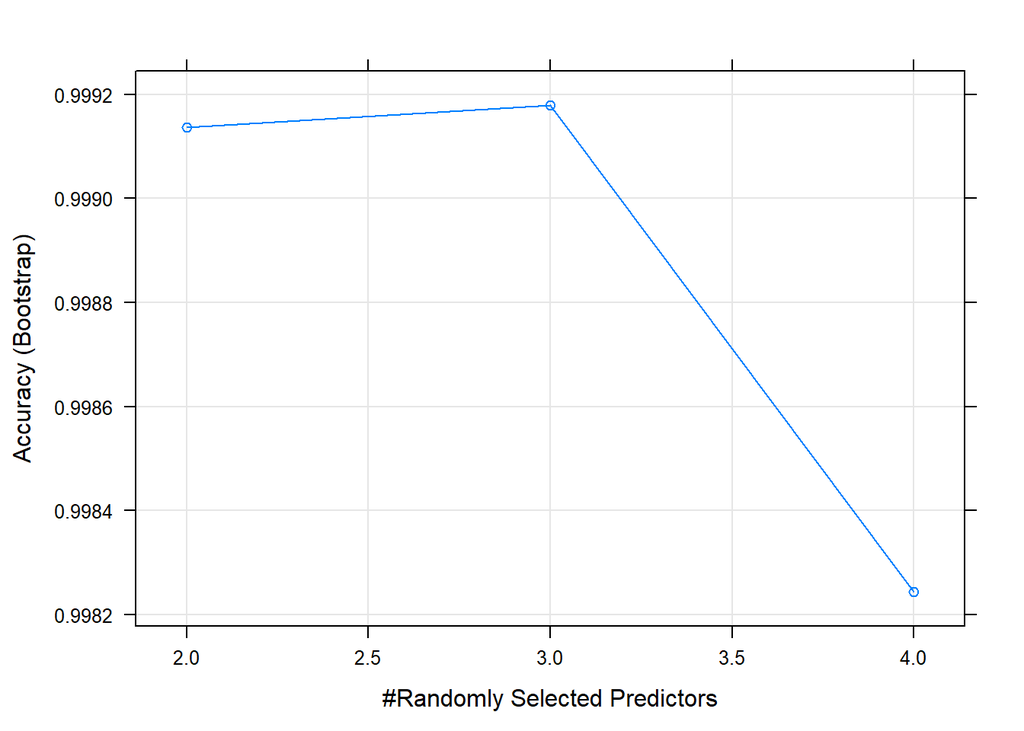

```r
plot(Training)
```

Above is The tuning process which is done by the caret package as a part of model evaluation on bootstrapped training samples

I would expect the Accuracy to about 99 Percent plus for out of sample errors

```r
predict.train(Training,Subset1)
```

```
##  [1] B A B A A E D B A A B C B A E E A B B B
## Levels: A B C D E
```